# TP3

## L.U : 527/20

Buscamos primero cargar todos los datos.

```r
df = read.csv("datos_alquiler.csv", stringsAsFactors = F)
```

Vemos todos los atributos de cada propiedad

```r
colnames(df)
```

```
 [1] "id"              "start_date"      "lat"             "lon"
 [5] "l1"              "l2"              "rooms"           "surface_total"
 [9] "surface_covered" "price"           "currency"        "property_type"
[13] "operation_type"  "fondo"
```

```r
table(df$property_type)
```

```
        Casa Departamento           PH
          27         1828           90
```

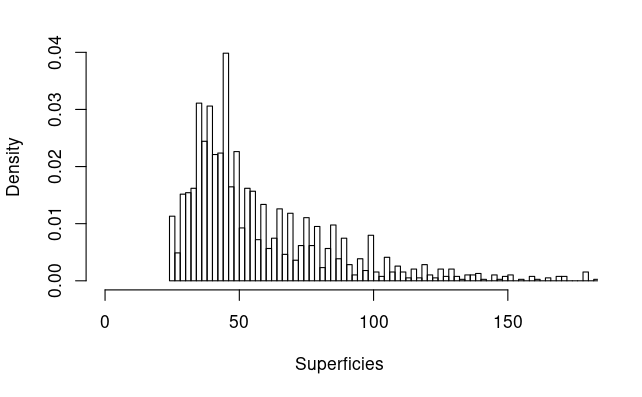

```r
mayor = quantile(df$surface_total, 0.99)
label = "Superficies "
hist(df$surface_total, breaks = 100,  freq = F, xlab = label, xlim = c(0,mayor), main ="")
```

```r
variables_Interes = c("price", "rooms", "surface_total", "fondo", "lat", "lon")
labelsInteres = c("Precio", "Habitaciones", "Superficie total", "Fondo", "lat", "lon")
variables_Interes2 = c("property_type", "start_date")
par(mfrow=c(2,4))
breaksVector = c(40,20,50,35,20,20)
plot(df[,variables_Interes[5]], df[,variables_Interes[6]], xlab = "Longitud", ylab = "Latitud")
for (i in 1:length(variables_Interes)) {
  #mayor = quantile(df[,variables_Interes[i]], 1, na.rm=T)
  label = labelsInteres[i]
  hist(df[,variables_Interes[i]], breaks = breaksVector[i],  freq = F, xlab = label, main ="")
}
```

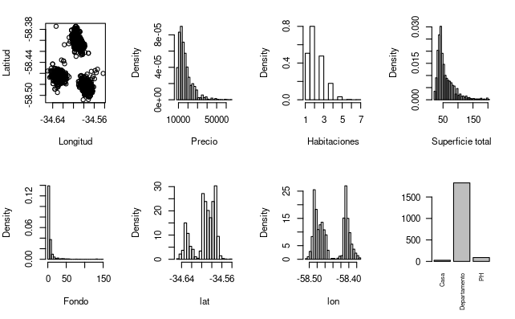

```r
with(df,{

tiposProp = table(property_type)
prop.table(table(tiposProp))
barplot(tiposProp, las=2, cex.names=0.65)
})
```

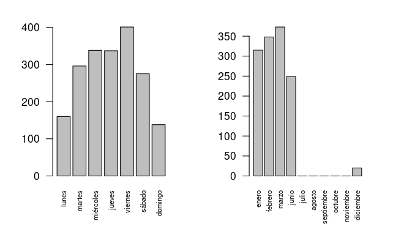

```r
df$start_date = as.Date(df$start_date)
df$diaEsp = factor(weekdays(df$start_date), levels = c("lunes", "martes", "miércoles", "jueves", "viernes","sábado", "domingo"))
df$mesEsp = factor(months(df$start_date), levels= c("enero", "febrero", "marzo", "junio", "julio","agosto", "septiembre", "octubre", "noviembre", "diciembre"))
df$diaIng = factor(weekdays(df$start_date), levels = c("Monday", "Tuesday","Wednesday", "Thursday", "Friday", "Saturday","Sunday"))
df$mesIng = factor(months(df$start_date), levels= c("January", "February", "March","April","May", "June", "July","August", "September", "October", "November", "December"))

with(df,{
par(mfrow=c(1,2))

dias = table(diaEsp) #Poner diaIng o diaEsp segun corresponda
prop.table(table(dias))
barplot(dias, las=2, cex.names=0.65)
meses = table(mesEsp) #Poner mesIng o mesEsp segun corresponda
prop.table(table(meses))
barplot(meses, las=2, cex.names=0.65, )
})
```

```r
ajusM1<-lm(price~1,data=df)
coe<-coef(ajusM1)
plot(df$price,  xlab = "Propiedades", ylab = "Precio")
abline(h = coe[1], col='red')
```

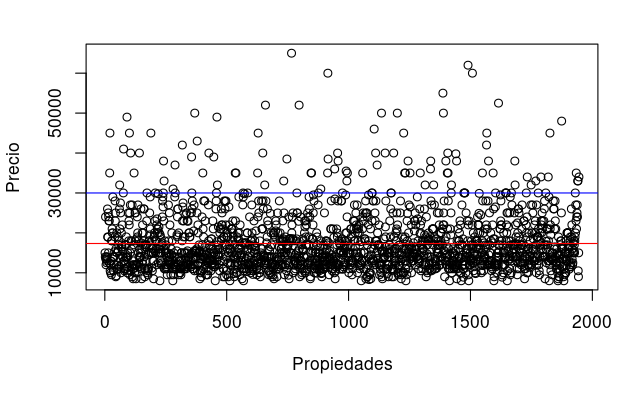

```r
abline(h = quantile(df$price, 0.95), col='blue')
```

```r
#h = lm(id ~ -1, data=df)
```

Como la linea roja viene de un modelo con un parametro constante que no depende de ninguna variable explicativa es el promedio (con loss function suma de diferencia de cuadrados). Podemos ver que la mayoria de las propiedades (el 95%) estan concentradas por debajo de la linea azul. Mientras que el 5% de propiedades mas caras empujan el promedio (linea roja) ligeramente arriba del centro de la nube negra de propiedades. Es decir el 5% de propiedades mas caras ocupa mas de la mitad del grafico.

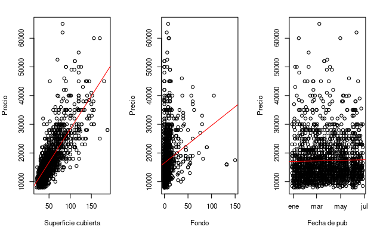

```r
with(df,{
par(mfrow=c(1,3))

plot(price~surface_covered, xlab ='Superficie cubierta', ylab = 'Precio')
precioSupC<-lm(price~surface_covered,data=df)
coeSP<-coef(precioSupC)
abline(coeSP, col = 'red')

plot(price~fondo, xlab ='Fondo', ylab = 'Precio')
precioFon<-lm(price~fondo,data=df)
coeFP<-coef(precioFon)
abline(coeFP, col = 'red')

plot(price~start_date, xlab ='Fecha de pub', ylab = 'Precio')
precioFecha<-lm(price~start_date,data=df)
coeFech<-coef(precioFecha)
abline(coeFech, col = 'red')
})
```

A los datos me remito, es muchisimo mas clara la relacion entre superficie cubierta y precio, que precio y fondo. Ni que hablar fecha de publicacion, en el cual se ve que mi coeficiente de grado 1 es practicamente 0. Con lo cual obtenemos algo similar al promedio de fecha de publicacion.

```r
precioSupC<-lm(price~surface_covered,data=df)
precioFecha<-lm(price~start_date,data=df)
precioFon<-lm(price~fondo,data=df)

summary(precioSupC)
```

```
Call:
lm(formula = price ~ surface_covered, data = df)

Residuals:
   Min     1Q Median     3Q    Max
-20670  -2470   -581   1833  40857

Coefficients:
                Estimate Std. Error t value Pr(>|t|)
(Intercept)     5168.986    244.641   21.13   <2e-16 ***
surface_covered  231.388      4.212   54.93   <2e-16 ***
---
Signif. codes:  0 ‘***’ 0.001 ‘**’ 0.01 ‘*’ 0.05 ‘.’ 0.1 ‘ ’ 1

Residual standard error: 4579 on 1943 degrees of freedom
Multiple R-squared:  0.6083,    Adjusted R-squared:  0.6081
F-statistic:  3018 on 1 and 1943 DF,  p-value: < 2.2e-16
```

```r
summary(precioFon)
```

```
Call:
lm(formula = price ~ fondo, data = df)

Residuals:
   Min     1Q Median     3Q    Max
-18612  -4544  -1935   2543  47412

Coefficients:
            Estimate Std. Error t value Pr(>|t|)
(Intercept) 16544.01     181.19   91.31   <2e-16 ***
fondo         130.45      13.35    9.77   <2e-16 ***
---
Signif. codes:  0 ‘***’ 0.001 ‘**’ 0.01 ‘*’ 0.05 ‘.’ 0.1 ‘ ’ 1

Residual standard error: 7142 on 1943 degrees of freedom
Multiple R-squared:  0.04682,   Adjusted R-squared:  0.04633
F-statistic: 95.45 on 1 and 1943 DF,  p-value: < 2.2e-16
```

```r
summary(precioFecha)
```

```
Call:
lm(formula = price ~ start_date, data = df)

Residuals:
   Min     1Q Median     3Q    Max
 -9575  -5049  -2136   2648  47722

Coefficients:
              Estimate Std. Error t value Pr(>|t|)
(Intercept) -40616.288  59867.212  -0.678    0.498
start_date       3.223      3.329   0.968    0.333

Residual standard error: 7314 on 1943 degrees of freedom
Multiple R-squared:  0.0004821, Adjusted R-squared:  -3.235e-05
F-statistic: 0.9371 on 1 and 1943 DF,  p-value: 0.3331
```

El R de cada modelo esta ordenado como el grafico. Superf cub > fondo > fecha de pub Notado que de los residuos, el mediano es siempre negativo, puedo deducir que el modelo esta prediciendo que el elemento del medio deberia ser mas grande que el que es. Esto puede deberse a la influencia de lo mucho mayor que es el precio cuando la superficie es mas grande, lo cual podria deberse a que el modelo lineal no se ajusta del todo bien por como estan distribuidos los precios en relacion a la sup.

```r
summary(precioSupC$residuals)
```

```
    Min.  1st Qu.   Median     Mean  3rd Qu.     Max.
-20669.9  -2469.8   -581.5      0.0   1833.1  40857.2
```

```r
summary(precioFon$residuals)
```

```
   Min. 1st Qu.  Median    Mean 3rd Qu.    Max.
 -18612   -4544   -1935       0    2543   47412
```

```r
summary(precioFecha$residuals)
```

```
   Min. 1st Qu.  Median    Mean 3rd Qu.    Max.
  -9575   -5049   -2136       0    2648   47722
```

```r
#sqrt(sum((precioSupC$residuals)**2))
```

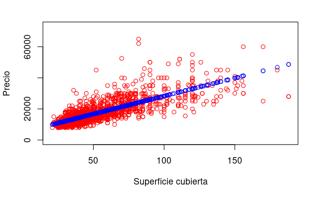

```r
plot(df$surface_covered, df$price, col='red', ylim = c(0 , 1.5*max(predict(precioSupC))), xlab = 'Superficie cubierta', ylab = 'Precio')
points( df$surface_covered, predict(precioSupC), col='blue')
```

La prediccion en azul mientras que los datos en rojo. Se puede ver como la ‘dispersion’ de los precios de superficie mas baja es menor, entonces uno puede tener una mejor prediccion, mientras que si aumenta mucho la superficie la variabilidad del precio es mayor, y el modelo le pifia mas.

```r
desempenioHastaPorcentaje = function(porcentaje){
  sup = quantile(df$surface_covered, porcentaje)
  sups = df[df$surface_covered <= sup,]$surface_covered
  precio = df[df$surface_covered <= sup,]$price
  modelo<-lm(precio~sups,data=df)
  return(summary(lm(precio~sups, data=df))$r.squared)

}
```

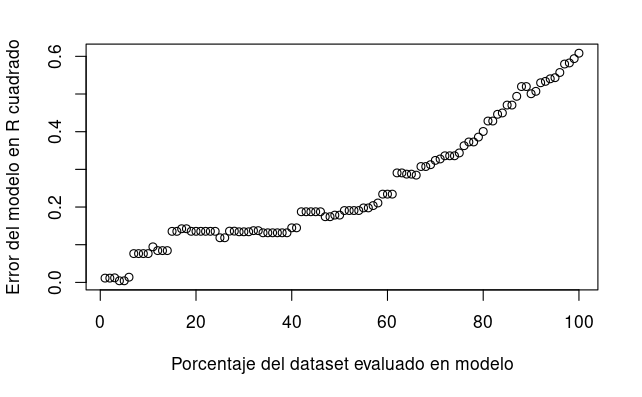

```r
porcentajes = c(1:100)/100
plot(sapply(porcentajes, desempenioHastaPorcentaje), xlab = 'Porcentaje del dataset evaluado en modelo', ylab = 'Error del modelo en R cuadrado')
```

```r
par(mfrow=c(1,3))
plot(precioSupC$residuals, xlab = 'Residuos superficie cubierta', ylab = 'Residuos')
abline(h=0,col= 'red')
```

```r
plot(precioFon$residuals, xlab = 'Residuos fondo', ylab = 'Residuos')
abline(h=0,col= 'red')
```

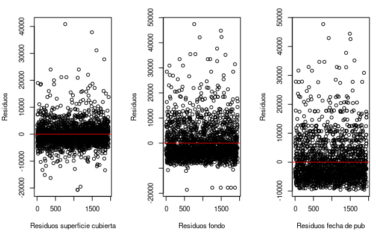

```r
plot(precioFecha$residuals, xlab = 'Residuos fecha de pub', ylab = 'Residuos')
abline(h=0,col= 'red')
```

Tal como esperabamos, el promedio del modulo los residuos es mas chico en superifice cubierta (grafico mas comprimido en 0) mientras que va aumentando debido a mayores diferencias al 0 en los otros graficos.

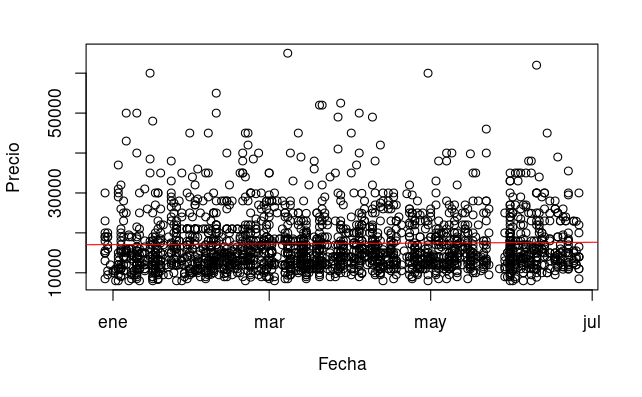

```r
modeloPrecioTiempo = lm(price~start_date, data = df)
plot(df$price~df$start_date, xlab="Fecha", ylab="Precio")
abline(coef(modeloPrecioTiempo), col='red')
```

No se aprecia la inflacion, es practicamente una constante.

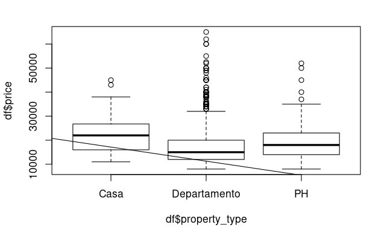

```r
modeloPrecioTipoPropiedad = lm(price~property_type, data = df)
boxplot(df$price~df$property_type)
coefProp = coef(modeloPrecioTipoPropiedad)
abline(modeloPrecioTipoPropiedad)
```

```r
print(coefProp)
```

```
              (Intercept) property_typeDepartamento           property_typePH
                22981.481                 -5852.160                 -3103.704
```

Lo que este modelo nos dice es que las casas por el simple hecho de ser casas tienen un valor promedio de 22981 (que actua como una ‘base’ para el resto de las propiedades. Mientras que ser un departamento te penaliza por -5852 menos el precio relativo a una casa y ser un PH tambien te penaliza por -3103. El modelo que hice solamente conecta precio de Casa vs Departamento

```r
lm(price~fondo+property_type+lat+lon+start_date+rooms, data = df)
```

```
Call:
lm(formula = price ~ fondo + property_type + lat + lon + start_date +
    rooms, data = df)

Coefficients:
              (Intercept)                      fondo  property_typeDepartamento
               4292535.95                     101.90                   -4872.07
          property_typePH                        lat                        lon
                 -5440.20                   77339.43                   30753.06
               start_date                      rooms
                    10.67                    4629.47
```